# Pareto family of Extended Weibull distribution coding

OTUNUGA OLUWASEUN

In this analysis, the codes for the Pareto family of Extended Weibull distribution by Otunuga, Oluwaseun Elizabeth, (“The Pareto-g Extended Weibull Distribution” (2017). Theses, Dissertations and Capstones. 1106. https://mds.marshall.edu/etd/1106) will be discussed.

This family consists of the Pareto (Type I) Extended Weibull Distribution or PEW for short, and the Pareto (Type II) Extended Weibull Distribution or otherwise called the Lomax Extended Weibull Distribution or LEW for short. The numbers of the parameters of PEW or LEW depend on the number of parameters for the extended Weibull distribution and type of the Pareto distribution.

Some properties of Pareto II Extended Weibull distributions are the hazard rate function, the CDF, and the PDF.

# The Hazard function of The Lomax Extended Weibull when $\alpha$ is 0

The Hazard function for LEW when $\alpha = 0$ is given as $(a*\beta*\gamma*x^{(\beta-1)})/(\lambda+(\gamma*x^\beta))$ where $\beta = b, a, \gamma = gam, \lambda = lam$ are the parameters. Here, different values for each parameters were used to get different plots.

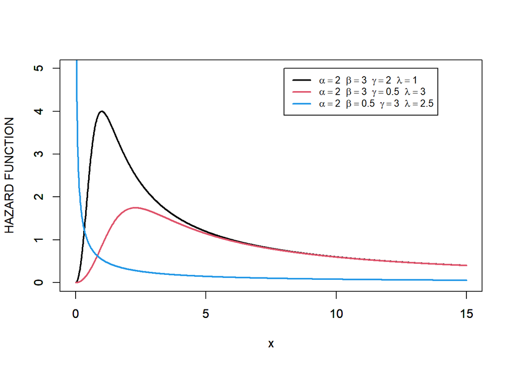

```r
x=seq(0,15,0.01)
a=2
b=3
gam=2
lam=1

f1=((a*b*gam*x^(b-1))/(lam+(gam*x^b)))


######
a=2
b=3
gam=.5
lam=3
f2=((a*b*gam*x^(b-1))/(lam+(gam*x^b)))


##############
a=2
b=.5
gam=3
lam=2.5
f3=((a*b*gam*x^(b-1))/(lam+(gam*x^b)))

##
par(mfrow=c(1,1), oma=c(0,0,0,0))
 plot(x,f1,lty= 1,type="l",lwd = 2,xlab="x",ylab="HAZARD FUNCTION",xlim=c(0,15), ylim=c(0,5),col="1")
 par(new=TRUE)
 plot(x,f2,lty= 1,type="l",lwd = 2, xlab=" ",ylab=" ",xlim=c(0,15), ylim=c(0,5),col="2")
 par(new=TRUE)
 plot(x,f3,lty= 1,type="l",lwd = 2, xlab="x",ylab="",xlim=c(0,15), ylim=c(0,5),col="4")

legend(8,5, legend=c(
expression(alpha==2~~ beta==3~~gamma==2~~lambda==1),
expression(alpha==2~~ beta==3~~gamma==0.5~~lambda==3),
expression(alpha==2~~ beta==0.5~~gamma==3~~lambda==2.5)),
cex=0.8,lty=c(1,1,1),col=c(1,2,4),lwd=2)
```

# The PDF of The Lomax Extended Weibull when $\alpha$ is 0

The PDF of LEW when $\alpha = 0$ is given as $(a*\beta*\gamma/\lambda)*x^{(\beta-1)}*(1+\gamma*x^{(\beta)}/\lambda)^{(-a-1)}$, where different values for $a, \beta = b, \gamma = gam, \& ~~\lambda = lam$ were used to get different plots.

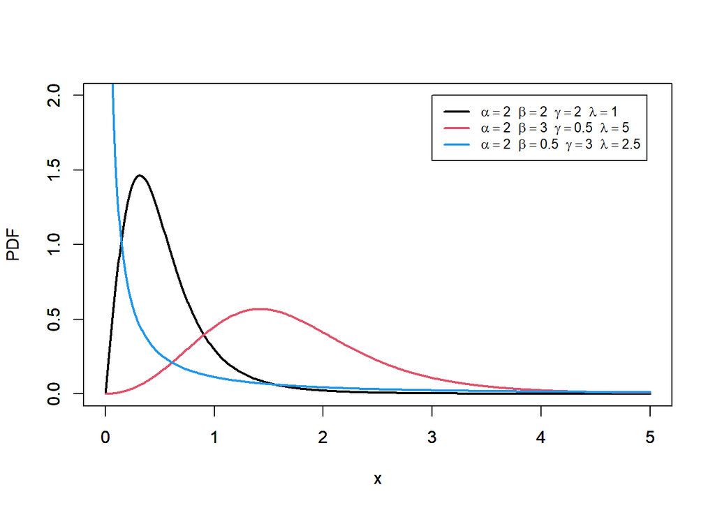

```r
x=seq(0,5,0.01)
a=2
b=2
gam=2
lam=1

f1=(a*b*gam*x^(b-1)/lam)*(1+gam*x^(b)/lam)^(-(a+1))


######
a=2
b=3
gam=.5
lam=5
f2=(a*b*gam*x^(b-1)/lam)*(1+gam*x^(b)/lam)^(-(a+1))


##############
a=2
b=.5
gam=3
lam=2.5
f3=(a*b*gam*x^(b-1)/lam)*(1+gam*x^(b)/lam)^(-(a+1))

##
par(mfrow=c(1,1), oma=c(0,0,0,0))
 plot(x,f1,lty= 1,type="l",lwd = 2,xlab="x",ylab="PDF",xlim=c(0,5), ylim=c(0,2),col="1")
 par(new=TRUE)
 plot(x,f2,lty= 1,type="l",lwd = 2, xlab=" ",ylab=" ",xlim=c(0,5), ylim=c(0,2),col="2")
 par(new=TRUE)
 plot(x,f3,lty= 1,type="l",lwd = 2, xlab="x",ylab="",xlim=c(0,5), ylim=c(0,2),col="4")

legend(3,2, legend=c(
expression(alpha==2~~ beta==2~~gamma==2~~lambda==1),
expression(alpha==2~~ beta==3~~gamma==0.5~~lambda==5),
expression(alpha==2~~ beta==0.5~~gamma==3~~lambda==2.5)), cex=0.8,lty=c(1,1,1),col=c(1,2,4),lwd=2)
```

# The CDF of The Lomax Extended Weibull when $\alpha$ is 0

The CDF of LEW when $\alpha = 0$ is given as $1-(1+\gamma*x^{(\beta)}/\lambda)^{(-a)}$, where different values are used for each parameters: $a, \beta = b, \gamma = gamma, \& ~~\lambda = lambda$ and x is used as the dataset.

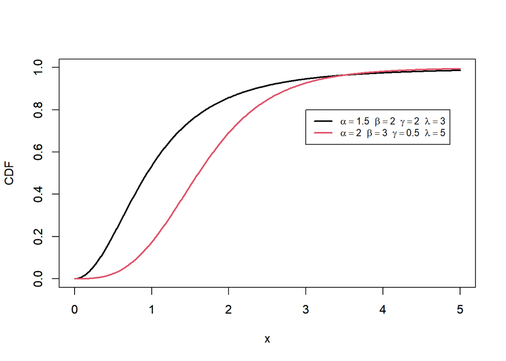

```r
x=seq(0,5,0.01)
a=1.5
b=2
gam=2
lam=3

f1=1-(1+(gam*x^(b))/lam)^(-a) ##Black


######
a=2
b=3
gam=.5
lam=5
f2=1-(1+gam*x^(b)/lam)^(-a) ## Red


##
par(mfrow=c(1,1), oma=c(0,0,0,0))
 plot(x,f1,lty= 1,type="l",lwd = 2,xlab="x",ylab="CDF",xlim=c(0,5), ylim=c(0,1),col="1")
 par(new=TRUE)
 plot(x,f2,lty= 1,type="l",lwd = 2, xlab=" ",ylab=" ",xlim=c(0,5), ylim=c(0,1),col="2")

legend(3,.8, legend=c(
expression(alpha==1.5~~ beta==2~~gamma==2~~lambda==3),
expression(alpha==2~~ beta==3~~gamma==0.5~~lambda==5)), cex=0.8,lty=c(1,1),col=c(1,2),lwd=2)
```

## Exceedances of Wheaton River flood data in $m^3/s$.

The data are the exceedances of flood peaks in ($m^3/s$) of the Wheaton River near Carcross in Yukon Territory, Canada. The data consists of 72 exceedances for the years 1958-1984, rounded to one decimal place. This distribution is often called ’peaks over thresholds’ model since it is used to model exceedances over threshold levels in flood control.

# Get the maximum likelihood estimate (mle) of the parameters of each distributions

Here we will show how to get the mle using exceedance of wheaton river data by using the LEW PDF and CDF as an example.

```r
library(AdequacyModel)
wheaton = c(1.7, 2.2, 14.4, 1.1, 0.4, 20.6, 5.3, 0.7, 1.9, 13.0, 12.0, 9.3, 1.4, 18.7, 8.5,
25.5, 11.6, 14.1, 22.1, 1.1, 2.5, 14.4, 1.7, 37.6, 0.6, 2.2, 39.0, 0.3, 15.0, 11.0, 7.3, 22.9,
1.7, 0.1, 1.1, 0.6, 9.0, 1.7, 7.0, 20.1, 0.4, 2.8, 14.1, 9.9, 10.4, 10.7, 30.0, 3.6, 5.6, 30.8,
13.3, 4.2, 25.5, 3.4, 11.9, 21.5, 27.6, 36.4, 2.7, 64.0,1.5, 2.5, 27.4, 1.0, 27.1, 20.2, 16.8,
5.3, 9.7, 27.5, 2.5, 27.0)
```

## LOMAX EXTENDED WEIBULL (LEW) DISTRIBUTION

The PDF of LEW when $\alpha = 0$ is given as $(a*\beta*\gamma/\lambda)*x^{(\beta-1)}*(1+\gamma*x^{(\beta)}/\lambda)^{(-a-1)}$, where $a, \beta = b, \gamma = gamma, \& ~~\lambda = lambda$ are the parameters.

```r
# LOMAX EXTENDED WEIBULL  - Probability density function.
pdf_lew <- function(par,x){
a = par[1]
b = par[2]
gamma = par[3]
lambda = par[4]
(a*b*gamma/lambda)*x^(b-1)*(1+gamma*x^(b)/lambda)^(-a-1)
}
```

# LOMAX EXTENDED WEIBULL (LEW)- Cumulative distribution function.

Using the Exceedances of Wheaton River flood data, we will obtain the MLE for each of the parameters for LEW.

The CDF of LEW when $\alpha = 0$ is given as $1-(1+\gamma*x^{(\beta)}/\lambda)^{(-a)}$, where $a, \beta = b, \gamma = gamma, \& ~~\lambda = lambda$ are the parameters

lew_1 is the result of the estimate obtained

```r
cdf_lew <- function(par,x){
a = par[1]
b = par[2]
gamma = par[3]
lambda = par[4]

1-(1+gamma*x^(b)/lambda)^(-a)
}

set.seed(0)

lew_1 = goodness.fit(pdf = pdf_lew, cdf = cdf_lew,
starts = c(1,1,1,1), data = wheaton, method = "PSO",
domain = c(0,Inf),mle = NULL, lim_inf = c(0,0,0,0),
lim_sup = c(5,5,5,5), S = 250, prop=0.1, N=500)
lew_1
```

```
## $W
## [1] 0.2051579
##
## $A
## [1] 1.149365
##
## $KS
##
##  One-sample Kolmogorov-Smirnov test
##
## data:  data
## D = 0.1387, p-value = 0.1253
## alternative hypothesis: two-sided
##
##
## $mle
## [1] 2.76613933 1.07611312 0.08757475 2.29065790
##
## $AIC
## [1] 517.0015
##
## $`CAIC `
## [1] 517.5985
##
## $BIC
## [1] 526.1082
##
## $HQIC
## [1] 520.6269
##
## $Value
## [1] 254.5008
```

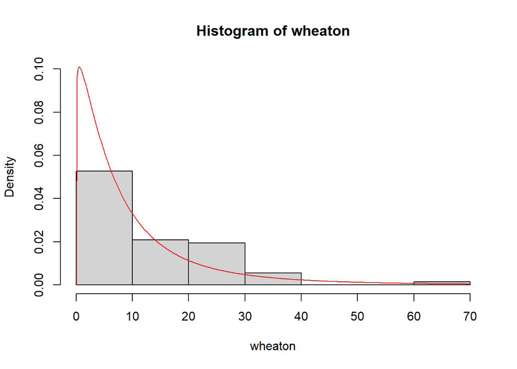

```r
x = seq(0, 70, length.out = 500)
hist(wheaton, probability = TRUE,ylim=c(0,.1))
lines(x, pdf_lew(x, par = lew_1$mle), col = "red")
```

##### Plot of all cumulative distributions with the empirical dataset (Exceedance of Wheaton river data)

Kumaraswamy Transmuted Pareto cumulative distribution and its parameter estimates.

```r
wheaton=c(1.7, 2.2, 14.4, 1.1, 0.4, 20.6, 5.3, 0.7, 1.9, 13.0, 12.0, 9.3, 1.4, 18.7, 8.5,
25.5, 11.6, 14.1, 22.1, 1.1, 2.5, 14.4, 1.7, 37.6, 0.6, 2.2, 39.0, 0.3, 15.0, 11.0, 7.3, 22.9,
1.7, 0.1, 1.1, 0.6, 9.0, 1.7, 7.0, 20.1, 0.4, 2.8, 14.1, 9.9, 10.4, 10.7, 30.0, 3.6, 5.6, 30.8,
13.3, 4.2, 25.5, 3.4, 11.9, 21.5, 27.6, 36.4, 2.7, 64.0,1.5, 2.5, 27.4, 1.0, 27.1, 20.2, 16.8,
5.3, 9.7, 27.5, 2.5, 27.0)

x=sort(wheaton)
```

```r
################### KwTP distribution ###################
a=4.2684
b=17.0139
lambda=-0.3687
alpha=0.2003
theta=0.1
F = 1-(1-(1-(theta/x)^alpha)^a*(1+lambda*(theta/x)^alpha)^a)^(b)
```

# The beta transmuted Pareto (BTP) CDF and its parameter estimates

The BTP CDF is given as $pbeta((1-(x0/x)^\alpha)*(1+\lambda*(x0/x)^\alpha),a,b)$

```r
##################################### BTP distribution
a=3.9118
b=17.3874
lambda= -0.8518
alpha= 0.1159
x0= 0.1
F1 = pbeta((1-(x0/x)^alpha)*(1+lambda*(x0/x)^alpha),a,b)
```

## The beta Pareto (BP) cumulative distribution and its parameter estimates

The BP CDF is given as $pbeta((1-(x0/x)^\alpha),a,b)$

```r
##################################### BP distribution
a=3.1473
b=85.7508
alpha=0.0088
x0=0.1

F2=pbeta((1-(x0/x)^alpha),a,b)
```

## The Transmuted Pareto (TP) cumulative distribution and its parameter estimates

The TP CDF is given as $(1-(x0/x)^\alpha)*(1+\lambda*(x0/x)^\alpha)$

```r
##################################### TP distribution
lambda=-0.952
alpha=0.349
x0=0.1

F3=(1-(x0/x)^alpha)*(1+lambda*(x0/x)^alpha)
```

## The Exponentiated Pareto (EP) cumulative distribution and its parameter estimates

The EP CDF is given as $pbeta((1-(x0/x)^\alpha)*(1+\lambda*(x0/x)^\alpha),a,b)$

```r
################################# EP
a=2.8797
b=1
alpha= 0.4241
x0=0.1
lambda=0
F4= pbeta((1-(x0/x)^alpha)*(1+lambda*(x0/x)^alpha),a,b)
```

## The Pareto cumulative distribution and its parameter estimates

Here is the CDF of the Pareto distribution: $1-(x0/x)^\alpha$

```r
################################# P
alpha=0.2438
x0=0.1
F5= 1-(x0/x)^alpha
```

## The Lomax Extended Weibull (LEW) cumulative distribution and its parameter estimates

$1-(1+\gamma*x^{(b)}/\lambda)^{-a}$ is the CDF of LEW

```r
################################# LEW
a=2.7661
b=1.0761
gamma=0.0876
lambda= 2.2907
F7=1-(1+gamma*x^(b)/lambda)^(-a)
```

## Cumulative Plots

```r
xrange=c(0,max(x))
yrange=c(0,1)
x<-sort(x)
E<-ecdf(x)
E
```

```
## Empirical CDF
## Call: ecdf(x)
##  x[1:58] =    0.1,    0.3,    0.4,  ...,     39,     64
```

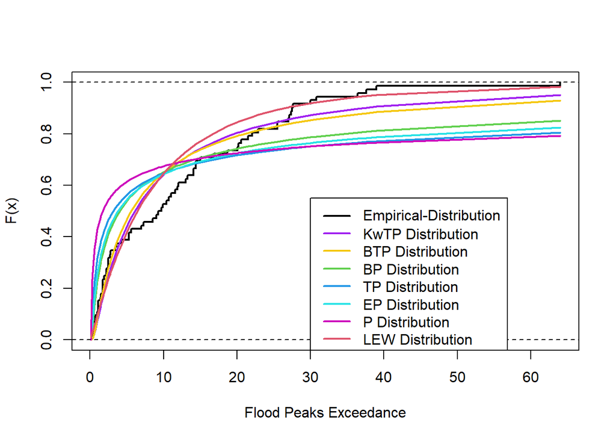

```r
ecdf<-E(c(x))
 par(mfrow=c(1,1),oma=c(0,0,0,0))
 plot(x,ecdf,lty=1,lwd=2,type="s",xlab="Flood Peaks Exceedance",ylab="F(x)",ylim=yrange,xlim=c(min(x),max(x)), col=1)
par(new=TRUE)
lines(x,F, xlim=xrange, lty=1, ylim=yrange, ylab="Density", lwd=2,col="purple", xlab="")
par(new=TRUE)
lines(x,F1, xlim=xrange, lty=1, ylim=yrange, ylab="Density", lwd=2,col=7, xlab="")
par(new=TRUE)
lines(x,F2, xlim=xrange, lty=1, ylim=yrange, ylab="Density", lwd=2,col=3, xlab="")
par(new=TRUE)
lines(x,F3, xlim=xrange, lty=1, ylim=yrange, ylab="Density", lwd=2,col=4, xlab="")
par(new=TRUE)
lines(x,F4, xlim=xrange, lty=1, ylim=yrange, ylab="Density", lwd=2,col=5, xlab="")
par(new=TRUE)
lines(x,F5, xlim=xrange, lty=1, ylim=yrange, ylab="Density", lwd=2,col=6, xlab="")
par(new=TRUE)
lines(x,F7, xlim=xrange, lty=1, ylim=yrange, ylab="Density", lwd=2,col=2, xlab="")
par(new=T)
abline(h=1, lty=2)
abline(h=0, lty=2)

legend(30,0.55, legend=c(expression("Empirical-Distribution"),expression("KwTP Distribution"),expression("BTP Distribution"),expression("BP Distribution"),
expression("TP Distribution"),expression("EP Distribution"),expression("P Distribution"),expression("LEW Distribution") ),lwd=2,lty=c(1,1,1), col=c(1,"purple",7,3,4,5,6,2))

box()
```